# Fire sparkles

The final touch we’re going to add are the sparkles. This final layer will add a little more interest to the explosion.

[video not shown]

For this effect we’re going to use the *sparkle.png* image inside the */assets* folder. It’s just a white circle with added blur which simulates light emission.

Create a new *Particles2D* and name it *SparkleParticles2D*. Drag the *sparkle.png* image to the *Texture* property.

Increase the *Amount* property to `32`, the *Explosiveness* to `0.2` and the *Randomness* to `1.0`. This gives us a good amount of particles and lifetime variety to work with in the *ParticlesMaterial*.

Let’s prevent the position of the particle system from affecting the position of the particles. To do this, toggle the *Local Coordinates* property to false.

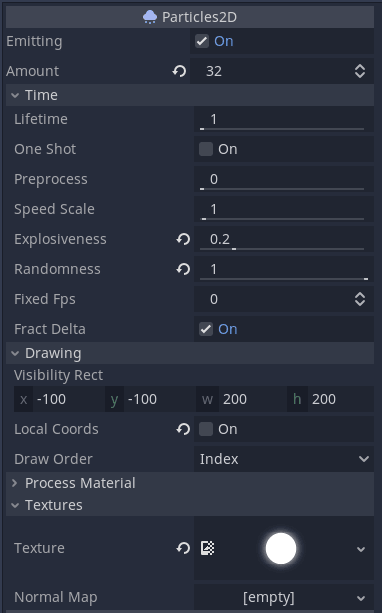

## Spreading the sparkles

The sparkles should appear in the explosion’s area and move away from the center as the fire bursts.

Create a new *ParticlesMaterial* as we have done before and change the *Emission Shape > Shape* to “Sphere”. Set the *Radius* to `50.0` to match the explosion area.

To make the sparkles move away from the explosion’s center we’re going to apply a constant force on each of them that points outwards from the particle system’s position. Increase the *Radial Accel > Accel* property to `200` and the *Accel Random* to `0.3` to allow each particle to accelerate differently.

Finally, increase the *Tangential Acceleration* to `100` to give a pleasing rotating effect.

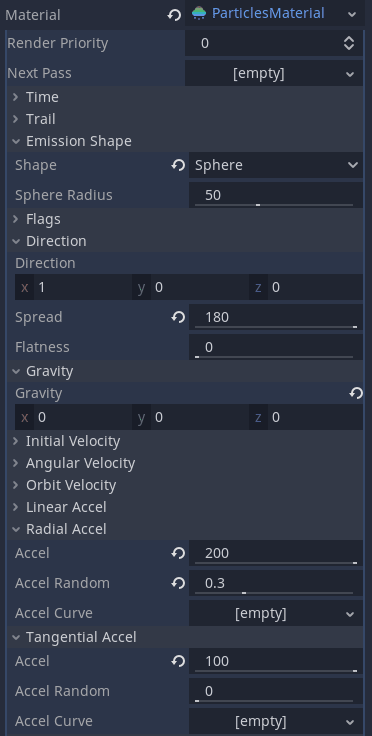

## Making them burn

To make the particles look like fire, go to the *Color > Color Ramp* property and use the same Gradient we used in the explosion’s fire burst.

If you’ve saved it in the FileSystem, you can drag it from the FileSystem dock directly to the *Color Ramp* property. In case you didn’t save it, select the *FireBurstParticles2D* and find the *ParticlesMaterial > Color Ramp* property, right-click on it and from the drop-down menu select “Copy”. Going back to the sparkles, right-click on the *Color Ramp* property slot to paste it. This is one way to reuse resources inside the same scene.

## Shining and fading

Now that the sparkles look like fire, it’s time to make them shine for a brief moment before their fire extinguishes and fades away.

In the *Scale* category, decrease the *Scale* property to `0.1` and increase the *Scale Random* property to `0.3` to add some variety to the size of the sparkles.

In the *Scale Curve* property, create a new “CurveTexture”. We’re going to use a mountain-shaped curve to achieve the fade in and out of each sparkle.

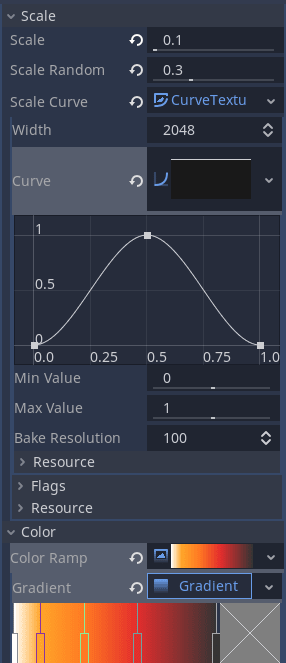

All our individual effects are in place and looking good!

Next, we are going to assemble them with an animation player to get our final explosion.